# Setting Up

## Q3

```python
print accuracy_score(outcomes, predictions)
```

```
Accuracy 79.35%
```

## Answer: 79.35%

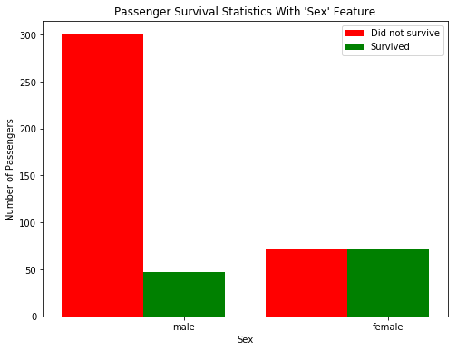

```python
# Visualizing other factors
vs.survival_stats(data, outcomes, 'Sex', ["Pclass == 3"])
```

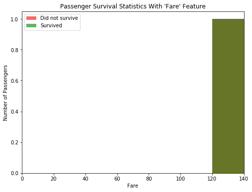

```python
vs.survival_stats(data, outcomes, 'Fare', ["Sex == 'male'","SibSp >= 0","Fare > 120","Fare < 140"])
```

[figure not shown]

```python
vs.survival_stats(data, outcomes, 'Fare', ["Sex == 'male'","Pclass == 1","Fare > 10","Fare < 40"])
```

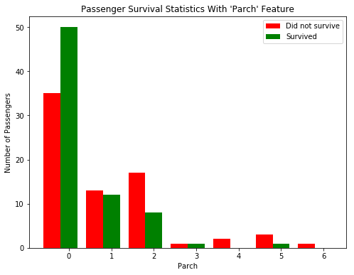

```python
vs.survival_stats(data, outcomes, 'Parch', ["Sex == 'female'","Pclass == 3"])
```

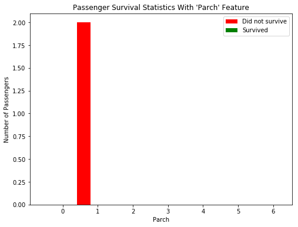

```python
vs.survival_stats(data, outcomes, 'Parch',["Sex == 'male'","SibSp > 1", "Parch == 1", "Fare > 20", "Age > 10"])
```

## Q4

```python
# Trying to get an accuracy > 80%
def predictions_3(data):
    """ Model with one feature:
            - Predict a passenger survived if they are female. """

    predictions = []
    for _, passenger in data.iterrows():

        if passenger['Sex'] == "female":
            if passenger['Pclass'] == 1 or passenger['Pclass'] == 2 :
                predictions.append(1)
            elif passenger['Pclass'] == 3 and passenger['Parch'] == 0 :
                predictions.append(1)
            else :
                predictions.append(0)
        else :
            if passenger['Age'] < 10:
                predictions.append(1)
            elif passenger['Fare'] > 300:
                predictions.append(1)
            elif passenger['Age'] <= 20 and passenger['Parch'] == 2 and passenger['SibSp'] < 2:
                predictions.append(1)
#             elif passenger['Pclass'] == 1 and passenger['Age'] > 20 and passenger['Age'] < 40:
#                 predictions.append(1)
#             elif passenger['Age'] >= 30 and passenger['Age'] <= 40 and passenger['Fare'] > 100:
#                 predictions.append(1)
            elif passenger['Pclass'] == 3 and passenger['Fare'] >= 40 and passenger['Fare'] <= 60:
                predictions.append(1)
#             elif passenger['Fare'] > 120 and passenger['Fare'] < 140:
#                 predictions.append(1)
            else :
                predictions.append(0)

    # Return our predictions
    return pd.Series(predictions)

# Make the predictions
predictions = predictions_3(data)
```

```python
print accuracy_score(outcomes, predictions)
```

```
Accuracy 81.59%
```

## Answer: 81.59%

Tried with several combinations and permutations. Was focussed on finding the corelation for only the Male gender. By that i was able to achieve 79.91% accuracy but was not able to increase upto 80%. Played around with Pclass and Age and Fare mostly. Also tried with SibSp and Parh but could not get a great combination. have left a few attempts in comments as well. Then shifted my attention towards the Female gender. Tried to find the corelations especially between the Pclass and pther variables and was able to do that between Pclass and Parch. The overall accuracy now 81.59%.

## Q5

## Answer:

Perdiction for Cancer, or any other disease for that matter, can be one of the applications of Supervised Learning. The outcome variable would be Yes or No prediction for the Cancer which can help the doctor in their diagnosis. We can use features like count of white blood cells, platelet count and other micro-biology factors to determine our prediction.